# Pylops - seismic interpolation (distributed)

### Author: M.Ravasi

In this notebook I will implement and compare different ways to perform interpolation of seismic data onto a regular grid from data acquired by an irregularly sampled array of receivers.

The problem of seismic data interpolation is a very simple one, yet very ill-posed and hard to solve. Our forward modelling operator is a simple *restriction* or *sampling* operator which is applied along the spatial direction(s).

$$\mathbf{y} = \mathbf{R} \mathbf{x}$$

where $\mathbf{y} = [\mathbf{y}_{R1}^T, \mathbf{y}_{R2}^T,..., \mathbf{y}_{RN^T}]^T$ and each vector $\mathbf{y}_{Ri}$ contains all time samples recorded in the seismic data at the specific receiver $R_i$. Similarly, $\mathbf{x} = [\mathbf{x}_{r1}^T, \mathbf{x}_{r2}^T,..., \mathbf{x}_{rM}^T]$, contains all traces at the regularly and finely sampled idea array of receivers $r_i$.

The forward model simply selects a subset of sources/receivers from the input vector which is assumed to have a fine and regularly sampled array of receivers (which is what we wish to recover via inversion), while its adjoint places those values at the correct locations in the input vector.

```python
%load_ext autoreload
%autoreload 2
%matplotlib inline

import warnings
warnings.filterwarnings('ignore')

import numpy as np
import matplotlib.pyplot as plt
import scipy as sp
import dask.array as da
import pylops_distributed

from scipy.signal import convolve

from pylops.utils.wavelets             import *
from pylops.utils.seismicevents        import *
from pylops_distributed.utils          import dottest
from pylops_distributed.basicoperators import *
from pylops_distributed.signalprocessing import *
from pylops_distributed.optimization.cg import cg, cgls
```

```
The autoreload extension is already loaded. To reload it, use:
  %reload_ext autoreload
```

```python
client = pylops_distributed.utils.backend.dask(processes=False, threads_per_worker=2,
                                               n_workers=2)
client
```

Client

- **Scheduler:** inproc://10.0.0.10/5268/13

- **Dashboard:** http://localhost:55910/status

Cluster

- **Workers:** 2

- **Cores:** 4

- **Memory:** 8.59 GB

# 2D

# Linear events

```python
###### Input parameters
par = {'ox':0,'dx':2,    'nx':140,
       'oy':0,'dy':2,    'ny':101,
       'ot':0,'dt':0.004,'nt':200,
       'f0': 20, 'nfmax': 210}

v       = 1500
t0_m    = [0.2, 0.4, 0.5]
theta_m = [0, 30, -60]
phi_m   = [0]
amp_m   = [1., -2, 0.5]

# Create axis
taxis, taxis2, xaxis, yaxis = makeaxis(par)

# Create wavelet
wav = ricker(taxis[:41], f0=par['f0'])[0]

# Generate model
m, x =  linear2d(xaxis, taxis, v, t0_m, theta_m, amp_m, wav)

# subsampling locations
perc_subsampling=0.4
Nsub=int(np.round(par['nx']*perc_subsampling))

iava = np.sort(np.random.permutation(np.arange(par['nx']))[:Nsub])

# Create restriction operator
Rop = Restriction(par['nx']*par['nt'], iava, dims=(par['nx'], par['nt']), dir=0, dtype='float64')
dottest(Rop,Nsub*par['nt'],par['nx']*par['nt'], verb=True, chunks=(Nsub*par['nt'],par['nx']*par['nt']))

x = da.from_array(x, chunks=(par['nx'], par['nt']))
y = Rop*x.flatten()
xadj = Rop.H*y.flatten()

y = y.reshape(Nsub, par['nt'])
xadj = xadj.reshape( par['nx'], par['nt'])
```

```
Dot test passed, v^T(Opu)=2815.783791 - u^T(Op^Tv)=2815.783791
```

```python
# FFT of full data
nfft=2**10
FFTop = FFT(dims=[nfft, par['nt']], dir=1, nfft=nfft, sampling=par['dt'], chunks=(nfft*par['nt'], nfft*nfft)) * \
        FFT(dims=[par['nx'], par['nt']], dir=0, nfft=nfft, sampling=par['dx'],
            chunks=(par['nx']*par['nt'], nfft*par['nt']))
f = np.fft.fftfreq(nfft, par['dt'])
kx= np.fft.fftfreq(nfft, par['dx'])

p = FFTop * x.ravel()
p = da.reshape(p, (nfft, nfft))
```

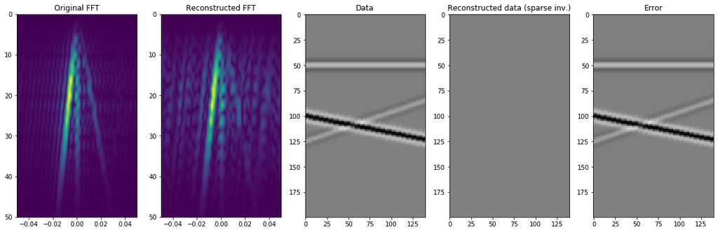

```python
Rprecop = Rop * FFTop.H
pinvf = cgls(Rprecop, y.ravel(), niter=20, compute=False)
xinvf = FFTop.H * pinvf

pinvf = da.reshape(pinvf, (nfft, nfft))
xinvf = np.real(da.reshape(xinvf, (par['nx'], par['nt'])).compute())

fig, axs = plt.subplots(1, 5, figsize=(20, 6))
axs[0].imshow(np.fft.fftshift(da.absolute(p[:, :nfft//2-1]).compute(),axes=0).T,
              extent=(-kx.max(), kx.max(), f[nfft//2-1], f[0]))
axs[0].set_title('Original FFT')
axs[0].axis('tight')
axs[0].set_ylim(50, 0)
axs[0].set_xlim(-0.05, 0.05)
axs[1].imshow(np.fft.fftshift(da.absolute(pinvf[:, :nfft//2-1]).compute(),axes=0).T,
              extent=(-kx.max(), kx.max(), f[nfft//2-1], f[0]))
axs[1].set_title('Reconstructed FFT')
axs[1].axis('tight')
axs[1].set_ylim(50, 0)
axs[1].set_xlim(-0.05, 0.05)
axs[2].imshow(x.T, cmap='gray', vmin=-2, vmax=2)
axs[2].set_title('Data')
axs[2].axis('tight');
axs[3].imshow(xinvf.T, cmap='gray', vmin=-2, vmax=2)
axs[3].set_title('Reconstructed data (sparse inv.)')
axs[3].axis('tight');
axs[4].imshow(x.T-xinvf.T, cmap='gray', vmin=-2, vmax=2)
axs[4].set_title('Error')
axs[4].axis('tight');
```